# Presentation of basic splitting of time series

D. Erik Boonstra

2024-01-17

# Purpose

This presentation of these results is provide a basic understanding of the times series and their relationships for different illnesses.

# Data

The data can all be read in using the following function.

```r
# Importing data ####
data_all <- read_all()

## Creating specific data sets
ccs_monthly_rates <- data_all$ccs_monthly_rates
```

These data do **not** include Medicaid at the moment because there is no data on related to CCS codes and Medicaid.

# Results

## Presentation of time series

The first time series examined is, of course, influenza (flu), as we are trying to determine if there is a causal relationship between the flu and other illnesses.

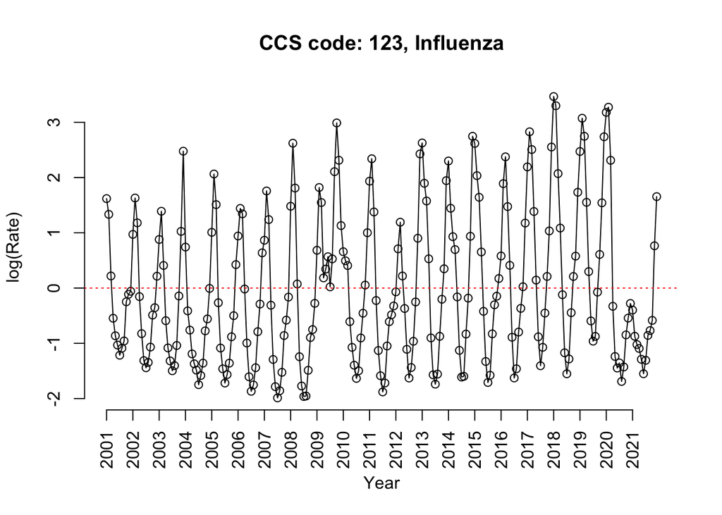

### Other illnesses

Now, we will examine other illnesses that could be related to flu by Erik’s naive understanding.

#### AMI

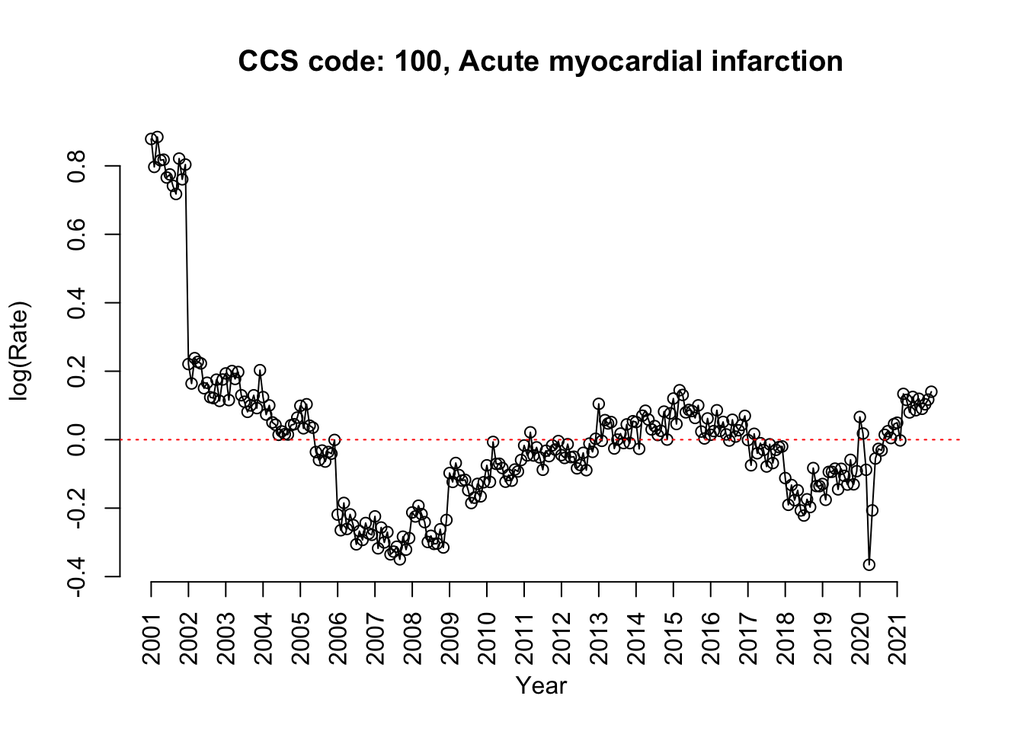

#### Pneumonia

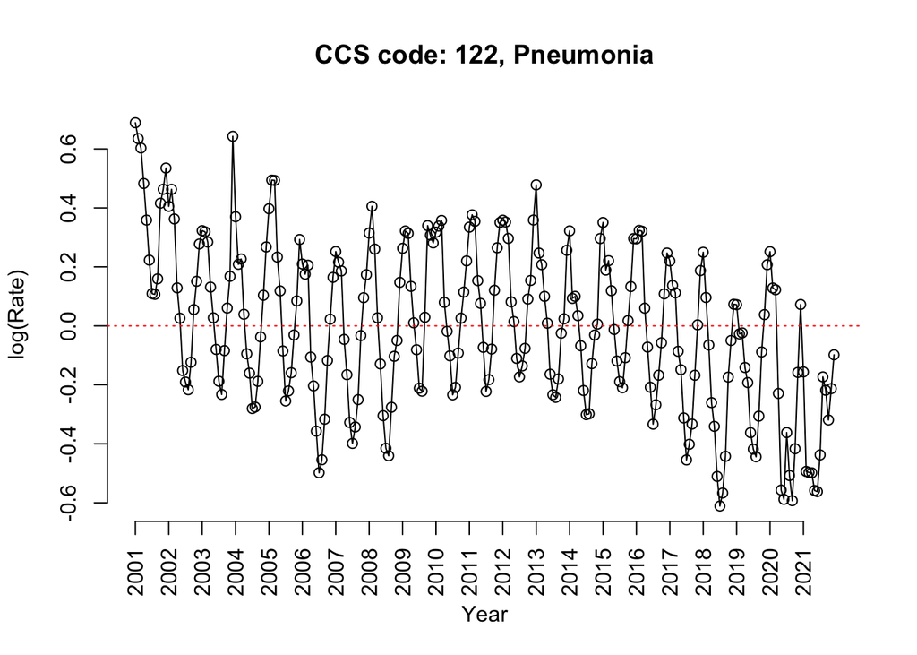

#### Tonsillitis

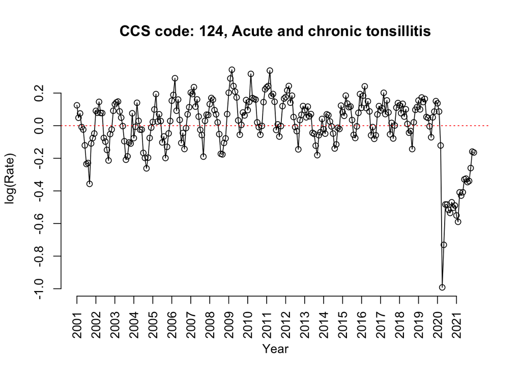

#### Bronchitis

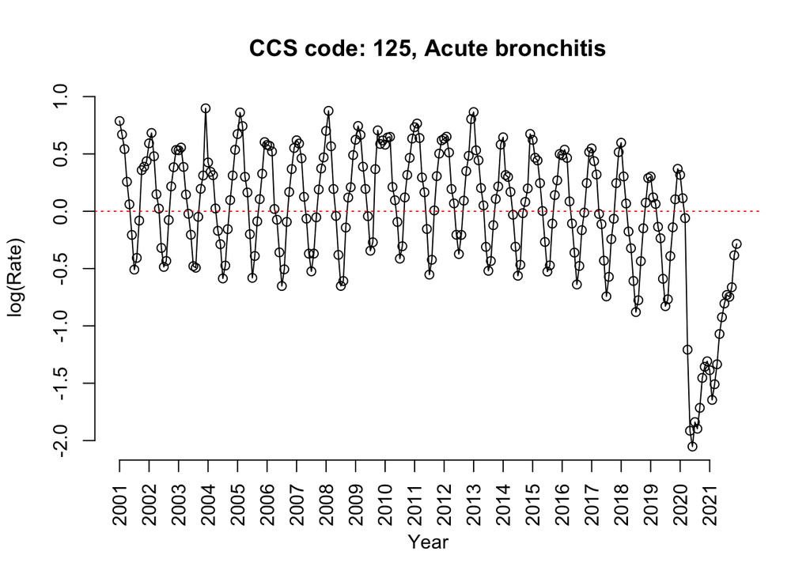

#### TB

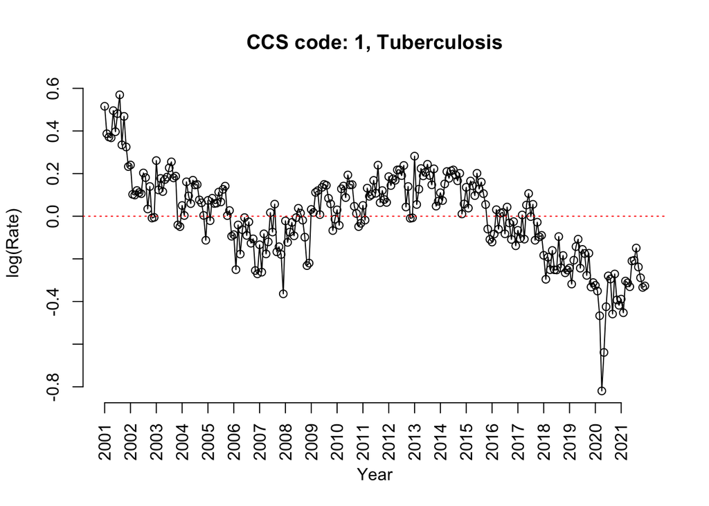

#### Other

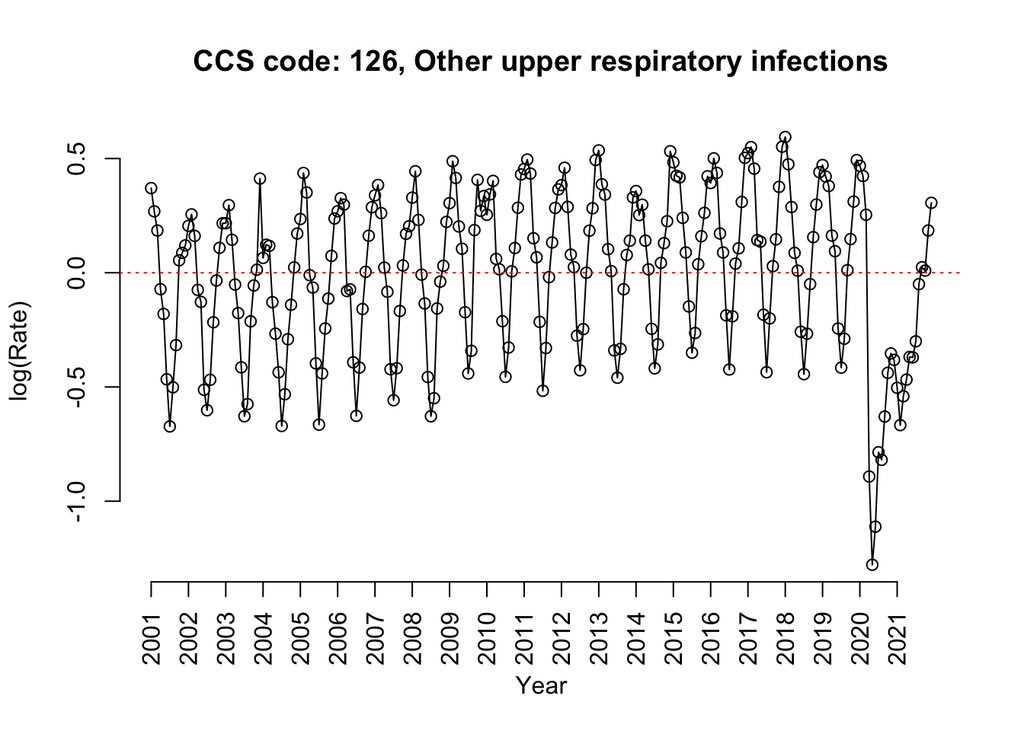

## Splitting of time series

Next, we will be do some basic splitting of the time series into there global, seasonal, and anomaly + white noise trends. The global trends will by a by-product of some functional form of timing of months throughout the study period. This means the global trend can be a linear or polynomial function. Then, the seasonal trend will be the same for each illness, which is the monthly means after the global trend has been removed. The leftover error from the seasonal model constructs the anomaly + white noise.

### Influenza

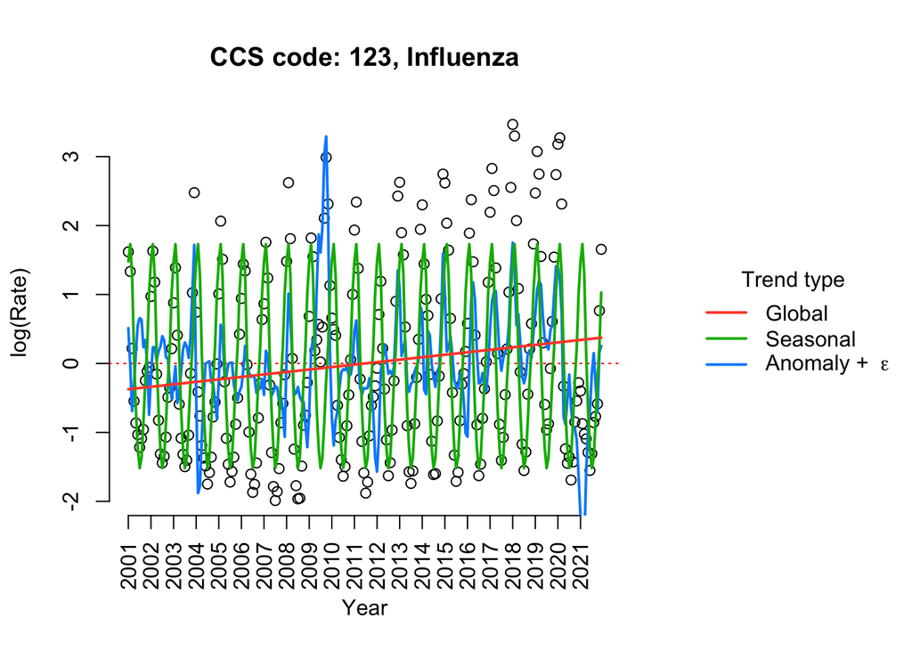

### AMI

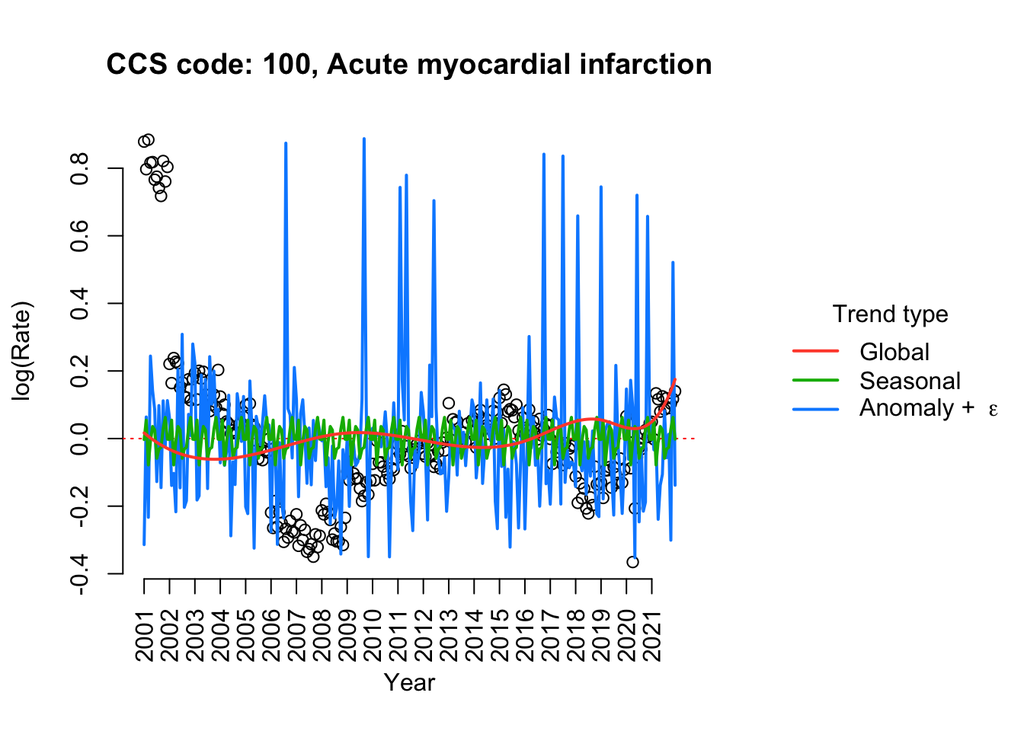

### Pneumonia

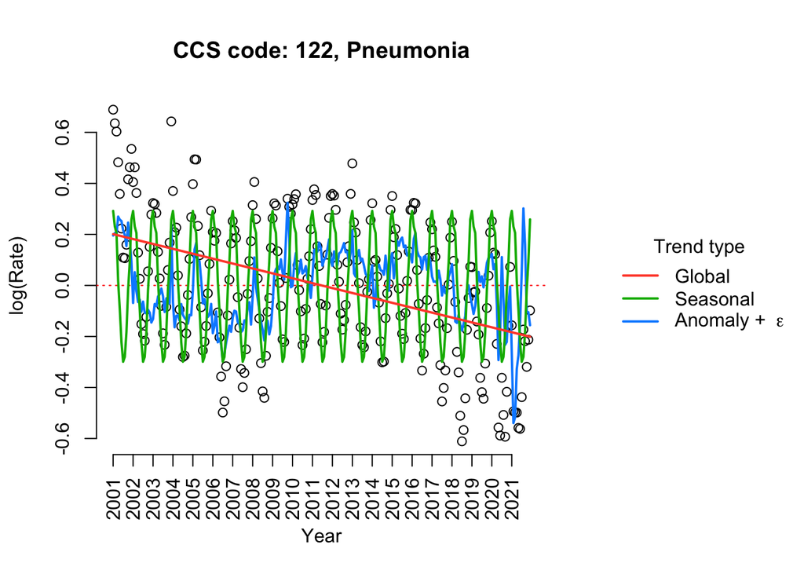

## Comparison of anomaly trends

With the time series broken into their global, seasonal, and anomaly + white noise trends, a comparison between the flu and other illnesses can be made when the anomaly + white noise trends are compared. In these plots, we hope to see some type of pattern, such as when the flu is large so is the other illness.

### AMI

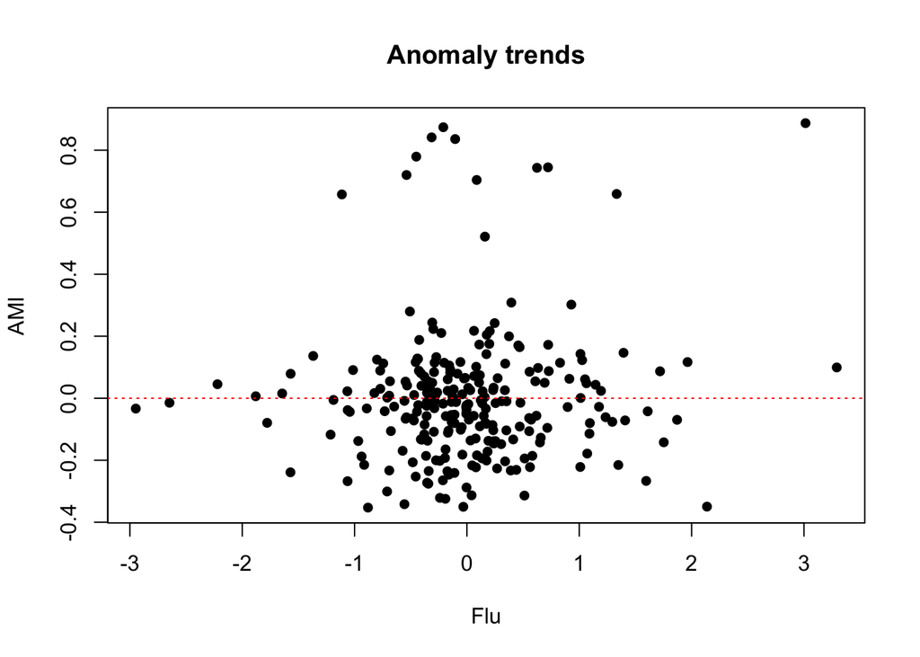

### Pneumonia

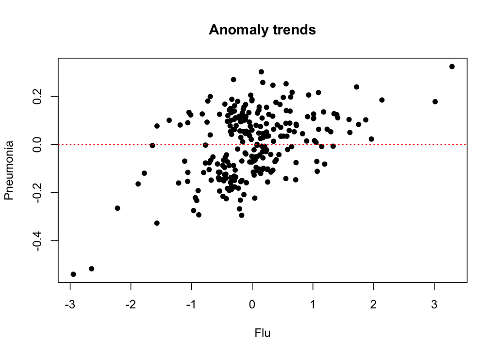